# PGLS pollen size by sex system

Claire Smith

2023-06-27

PGLS analysis based on tutorial by Roger Mundry from the Chapter 6 practical material from Modern Phylogenetic Comparative Methods and Their Application in Evolutionary Biology (Springer 2014). Link: https://www.mpcm-evolution.com/practice/online-practical-material-chapter-6/chapter-6-1exercises-testing-assumptions-statistical-issues-framework-phylogenetic-generalized-least-squares

A. Is there an effect of sex system on pollen number? Do we see a size-number tradeoff across species (i.e. is there an effect of pollen size on number)?

model: pollen production/anther ~ pollen size + sex system + collector

B. Does pollen size vary in wind-pollinated species according to their sex system? Specifically, do dioecious species make smaller pollen (to facilitate long-distance dispersal)?

model: pollen size ~ sex system + collector

- pollen production/anther is average pollen produced per anther per species
- pollen size is the mean diameter of pollen grains per species
- sex system is a categorical test predictor with 3 levels (dioecious, monoecious, hermaphroditic)
- collector is a categorical control predictor with 2 levels (CS, JF), to control for any effects on pollen load depending on who collected the data

```r
# Load packages
library(dplyr)
library(car)
library(V.PhyloMaker2)
library(ape)
library(dplyr)
library(caper)

library(lme4)
library(lmerTest)
library(ggplot2)
library(emmeans)

source("theme_cs.R")
```

```r
#read the phylogeny into an R object
sizenum_tree <- read.tree("processed-data/sizenum_tree.nwk")
#inspect the tree
str(sizenum_tree)
```

```
## List of 4
##  $ edge       : int [1:55, 1:2] 30 31 32 33 33 32 34 35 35 34 ...
##  $ edge.length: num [1:55] 4.08 11.81 13.13 106.74 106.74 ...
##  $ Nnode      : int 27
##  $ tip.label  : chr [1:29] "Ambrosia_artemisiifolia" "Plantago_lanceolata" "Chenopodium_album" "Amaranthus_retroflexus" ...
##  - attr(*, "class")= chr "phylo"
##  - attr(*, "order")= chr "cladewise"
```

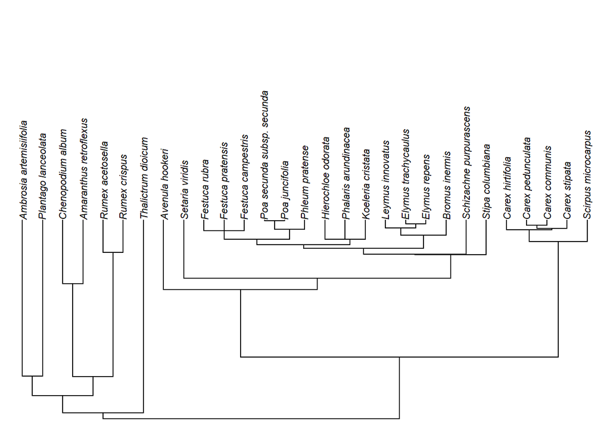

```r
#sizenum_tree is a tree with 29 tips and 27 internal nodes
#plot the tree:
plot.phylo(x=sizenum_tree, cex=0.7, direction="upwards", no.margin=TRUE)
```

```r
## read in data with pollen size/number
sizenum <- read.csv("processed-data/size-prod-norep.csv", stringsAsFactors = T)
# head(sizenum)
# summary(sizenum)
# str(sizenum)

# I want the data to be at the species level -- I'll take species-wide averages
sizenum_sp <- sizenum %>% group_by(Sex_sys, Species, source) %>%
  filter(!is.na(Avg_diam) & !is.na(Avg_pol_anth)) %>%
  summarize(Avg_pol_anth = mean(Avg_pol_anth),
            Avg_diam = mean(Avg_diam),
            N = n()) %>%
  filter(N>=5) %>% # Keep only species with at least 5 individuals
  droplevels()
# head(sizenum_sp)
# summary(sizenum_sp)
# str(sizenum_sp) # 32 species
# View(sizenum_sp)

# Add useful columns..
sizenum_sp <- sizenum_sp %>%
  # Update species names to match tree
  # Agropyron trachycaulum => Elymus trachycaulus
  # Elymus innovatus => Leymus innovatus
  mutate(Species = gsub("Agropyron trachycaulum", "Elymus trachycaulus", Species),
         Species = gsub("Elymus innovatus", "Leymus innovatus", Species)) %>%
  # Species_ to match style of species names in phylogeny
  mutate(Species_ = gsub(" ", "_", Species)) %>%
  # create column "Collector" describing who took the data
  mutate(collector = as.factor(case_when(source == "CS2021" ~ "CS",
                               source == "JF2001" ~ "JF",
                               source == "JF2004" ~ "JF"))) %>%
  as.data.frame()

#inspect sizenum.data
# str(sizenum_sp) # 32 species
# Key variables:
#"Avg_pol_anth" - mean pollen production per anther, per species
#"Avg_diam" - the mean pollen diameter (per flower) per species in nm, averaged within individuals then across individuals to get a species-wide mean
#"collector" - a factor with 2 levels to control for who collected the data (CS or JF)
#"Sex_sys" - a factor with 3 levels specifying a species' sex system (dioecious, monoecious, or hermaphroditic).
#check whether there are any missing values in "sn.dat.sel":
# sum(is.na(sizenum_sp)) # no missing data
```

Pre model-fitting checks:

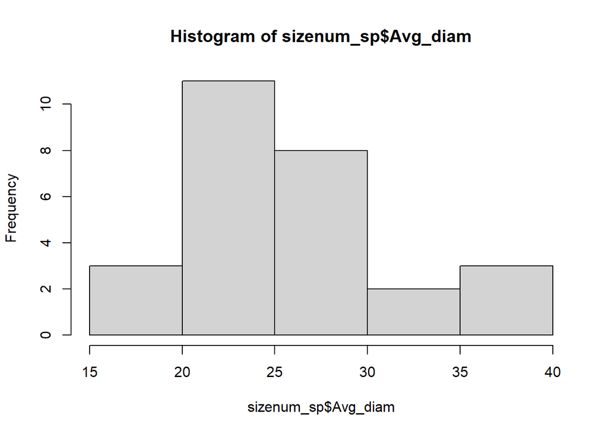

```r
#inspect the distribution of size and number
hist(sizenum_sp$Avg_diam) #looks okay, not too skewed, no obvious outliers
```